# LBB

Inspiration The data-set aims to answer the following key questions:

1. Does various predicting factors which has been chosen initially really affect the Life expectancy? What are the predicting variables actually affecting the life expectancy?
2. Should a country having a lower life expectancy value(<65) increase its healthcare expenditure in order to improve its average lifespan?
3. Does Life Expectancy has positive or negative correlation with eating habits, lifestyle, exercise, smoking, drinking alcohol etc.
4. Do densely populated countries tend to have lower life expectancy?

```r
library(dplyr)
library(ggplot2)
library(GGally)
library(tidyr)
library(MLmetrics)
library(car)
```

```r
options(scipen = 999)
```

```r
life <- read.csv("Life Expectancy Data.csv")
```

```r
life <- life %>%
  drop_na() %>%
  mutate(Country = as.factor(Country),
         Status = as.factor(Status),
         Year = as.factor(Year))
```

```r
str(life)
```

[output not shown]

```r
colSums(is.na(life))
```

[output not shown]

```r
life_low <- life %>%
  filter(Life.expectancy < 65) %>%
  select(c("Life.expectancy","Total.expenditure"))
```

```r
model_low <- lm(formula = Life.expectancy~Total.expenditure, data = life_low)
summary(model_low)
```

```
Call:
lm(formula = Life.expectancy ~ Total.expenditure, data = life_low)

Residuals:
     Min       1Q   Median       3Q      Max
-13.7376  -2.9252   0.8084   4.4974   8.8206

Coefficients:
                  Estimate Std. Error t value             Pr(>|t|)
(Intercept)        59.4368     0.6787  87.573 < 0.0000000000000002 ***
Total.expenditure  -0.3565     0.1096  -3.253              0.00123 **
---
Signif. codes:  0 ‘***’ 0.001 ‘**’ 0.01 ‘*’ 0.05 ‘.’ 0.1 ‘ ’ 1

Residual standard error: 5.397 on 437 degrees of freedom
Multiple R-squared:  0.02364,   Adjusted R-squared:  0.02141
F-statistic: 10.58 on 1 and 437 DF,  p-value: 0.00123
```

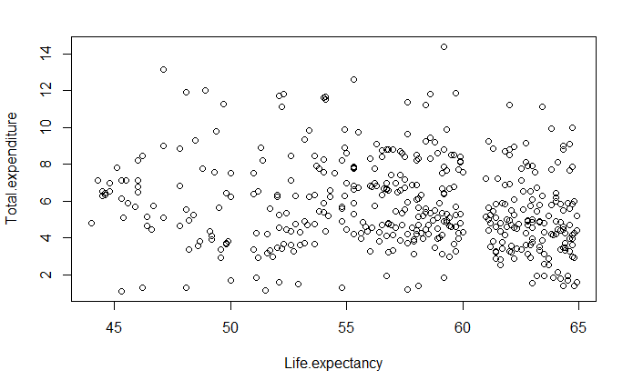

```r
plot(life_low)
abline(model_low)
```

```r
cor(life_low)
```

```
                  Life.expectancy Total.expenditure
Life.expectancy         1.0000000        -0.1537677
Total.expenditure      -0.1537677         1.0000000
```

> negative correlation, so there is no need to increase expenditure

```r
life_exp <- life %>%
  select(-c("Country","Year","Status"))
```

```r
str(life_exp)
```

```
'data.frame':   1649 obs. of  19 variables:
 $ Life.expectancy                : num  65 59.9 59.9 59.5 59.2 58.8 58.6 58.1 57.5 57.3 ...
 $ Adult.Mortality                : int  263 271 268 272 275 279 281 287 295 295 ...
 $ infant.deaths                  : int  62 64 66 69 71 74 77 80 82 84 ...
 $ Alcohol                        : num  0.01 0.01 0.01 0.01 0.01 0.01 0.01 0.03 0.02 0.03 ...
 $ percentage.expenditure         : num  71.3 73.5 73.2 78.2 7.1 ...
 $ Hepatitis.B                    : int  65 62 64 67 68 66 63 64 63 64 ...
 $ Measles                        : int  1154 492 430 2787 3013 1989 2861 1599 1141 1990 ...
 $ BMI                            : num  19.1 18.6 18.1 17.6 17.2 16.7 16.2 15.7 15.2 14.7 ...
 $ under.five.deaths              : int  83 86 89 93 97 102 106 110 113 116 ...
 $ Polio                          : int  6 58 62 67 68 66 63 64 63 58 ...
 $ Total.expenditure              : num  8.16 8.18 8.13 8.52 7.87 9.2 9.42 8.33 6.73 7.43 ...
 $ Diphtheria                     : int  65 62 64 67 68 66 63 64 63 58 ...
 $ HIV.AIDS                       : num  0.1 0.1 0.1 0.1 0.1 0.1 0.1 0.1 0.1 0.1 ...
 $ GDP                            : num  584.3 612.7 631.7 670 63.5 ...
 $ Population                     : num  33736494 327582 31731688 3696958 2978599 ...
 $ thinness..1.19.years           : num  17.2 17.5 17.7 17.9 18.2 18.4 18.6 18.8 19 19.2 ...
 $ thinness.5.9.years             : num  17.3 17.5 17.7 18 18.2 18.4 18.7 18.9 19.1 19.3 ...
 $ Income.composition.of.resources: num  0.479 0.476 0.47 0.463 0.454 0.448 0.434 0.433 0.415 0.405 ...
 $ Schooling                      : num  10.1 10 9.9 9.8 9.5 9.2 8.9 8.7 8.4 8.1 ...
```

```r
sapply(life, n_distinct)
```

```
                        Country                            Year                          Status
                            133                              16                               2
                Life.expectancy                 Adult.Mortality                   infant.deaths
                            320                             369                             165
                        Alcohol          percentage.expenditure                     Hepatitis.B
                            833                            1645                              83
                        Measles                             BMI               under.five.deaths
                            603                             538                             199
                          Polio               Total.expenditure                      Diphtheria
                             68                             669                              66
                       HIV.AIDS                             GDP                      Population
                            167                            1649                            1647
           thinness..1.19.years              thinness.5.9.years Income.composition.of.resources
                            179                             185                             548
                      Schooling
                            147
```

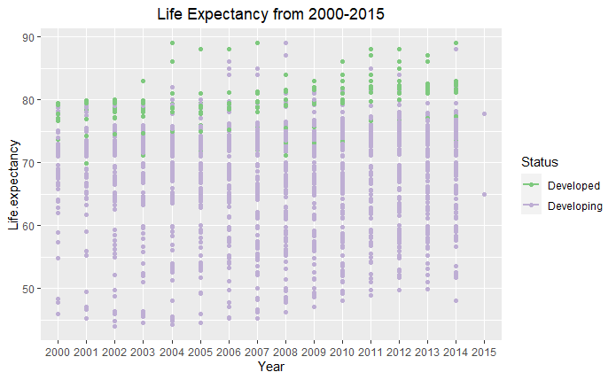

```r
ggplot(data=life,mapping=aes(Year,Life.expectancy,color=Status))+
  geom_point()+
  scale_color_brewer(palette="Accent")+
  geom_smooth(method="lm",se=FALSE)+
  labs(title="Life Expectancy from 2000-2015")+
  theme(plot.title = element_text(hjust = 0.5))
```

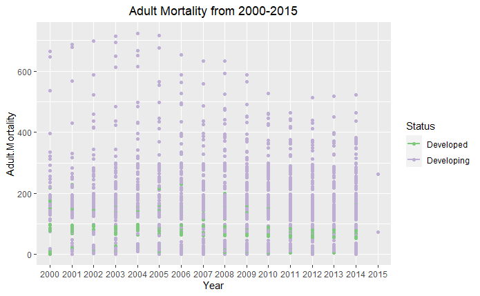

```r
ggplot(data=life,mapping=aes(Year,Adult.Mortality,color=Status))+
  geom_point()+
  scale_color_brewer(palette="Accent")+
  geom_smooth(method="lm",se=FALSE)+
  labs(title="Adult Mortality from 2000-2015")+
  theme(plot.title = element_text(hjust = 0.5))
```

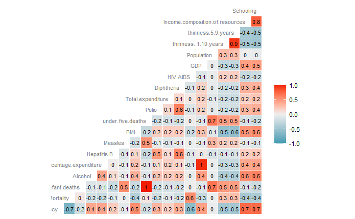

```r
ggcorr(life_exp, label = TRUE, label_size = 3, hjust = 1, size = 3, color = "grey50")
```

> > Kesimpulan : Schooling , Income Composition of Resources, Adult.Mortality, HIV.AIDS, BMI

```r
model_all <- lm(formula = Life.expectancy~., data = life_exp)
summary(model_all)
```

```
Call:
lm(formula = Life.expectancy ~ ., data = life_exp)

Residuals:
     Min       1Q   Median       3Q      Max
-17.0176  -2.0454  -0.0185   2.2260  11.9157

Coefficients:
                                        Estimate       Std. Error t value             Pr(>|t|)
(Intercept)                     53.2815590198721  0.7358126406486  72.412 < 0.0000000000000002 ***
Adult.Mortality                 -0.0168885301997  0.0009472912705 -17.828 < 0.0000000000000002 ***
infant.deaths                    0.0936938378330  0.0106765961044   8.776 < 0.0000000000000002 ***
Alcohol                         -0.0543483450424  0.0306070454392  -1.776               0.0760 .
percentage.expenditure           0.0003776826235  0.0001804691153   2.093               0.0365 *
Hepatitis.B                     -0.0055824997053  0.0044461852137  -1.256               0.2095
Measles                         -0.0000086173382  0.0000108065835  -0.797               0.4253
BMI                              0.0334980599049  0.0060106760259   5.573         0.0000000292 ***
under.five.deaths               -0.0704701961145  0.0077282061768  -9.119 < 0.0000000000000002 ***
Polio                            0.0078363788927  0.0051632463325   1.518               0.1293
Total.expenditure                0.0797522210770  0.0407415696170   1.958               0.0505 .
Diphtheria                       0.0143889186959  0.0059383017027   2.423               0.0155 *
HIV.AIDS                        -0.4382980476500  0.0178758984580 -24.519 < 0.0000000000000002 ***
GDP                              0.0000138327405  0.0000283772875   0.487               0.6260
Population                      -0.0000000006917  0.0000000017525  -0.395               0.6931
thinness..1.19.years            -0.0086702286839  0.0531024439158  -0.163               0.8703
thinness.5.9.years              -0.0512278223876  0.0524179265759  -0.977               0.3286
Income.composition.of.resources  9.8241467234536  0.8339594781239  11.780 < 0.0000000000000002 ***
Schooling                        0.8783349550519  0.0593903821788  14.789 < 0.0000000000000002 ***
---
Signif. codes:  0 ‘***’ 0.001 ‘**’ 0.01 ‘*’ 0.05 ‘.’ 0.1 ‘ ’ 1

Residual standard error: 3.596 on 1630 degrees of freedom
Multiple R-squared:  0.8347,    Adjusted R-squared:  0.8329
F-statistic: 457.4 on 18 and 1630 DF,  p-value: < 0.00000000000000022
```

```r
vif(model_all)
```

```
                Adult.Mortality                   infant.deaths                         Alcohol
                       1.795984                      212.177699                        1.938381
         percentage.expenditure                     Hepatitis.B                         Measles
                      12.847295                        1.651864                        1.514114
                            BMI               under.five.deaths                           Polio
                       1.796920                      201.999311                        1.712620
              Total.expenditure                      Diphtheria                        HIV.AIDS
                       1.118562                        2.092936                        1.482079
                            GDP                      Population            thinness..1.19.years
                      13.516874                        1.943391                        7.602562
             thinness.5.9.years Income.composition.of.resources                       Schooling
                       7.584519                        2.971489                        3.512993
```

```r
life_exp <- life_exp %>%
  select(-c("percentage.expenditure","under.five.deaths"))
```

```r
set.seed(123)
samplesize <- round(0.7 * nrow(life_exp), 0)
index <- sample(seq_len(nrow(life_exp)), size = samplesize)

data_train <- life_exp[index, ]
data_test <- life_exp[-index, ]
```

```r
model_all1 <- lm(formula = Life.expectancy~., data = data_train)
summary(model_all1)
```

```
Call:
lm(formula = Life.expectancy ~ ., data = data_train)

Residuals:
     Min       1Q   Median       3Q      Max
-13.4301  -2.0632   0.0488   2.3458  12.0615

Coefficients:
                                       Estimate      Std. Error t value             Pr(>|t|)
(Intercept)                     52.630454612090  0.893662383673  58.893 < 0.0000000000000002 ***
Adult.Mortality                 -0.018753675757  0.001140494418 -16.443 < 0.0000000000000002 ***
infant.deaths                   -0.003946595414  0.001415661815  -2.788              0.00539 **
Alcohol                         -0.098050854704  0.036795918415  -2.665              0.00781 **
Hepatitis.B                     -0.001430391505  0.005519089870  -0.259              0.79555
Measles                          0.000026170606  0.000013502066   1.938              0.05284 .
BMI                              0.036361321707  0.007488119925   4.856       0.000001365941 ***
Polio                            0.014953814850  0.006379346370   2.344              0.01924 *
Total.expenditure                0.063045802024  0.050065180579   1.259              0.20819
Diphtheria                       0.010125783100  0.007182107989   1.410              0.15885
HIV.AIDS                        -0.425373572930  0.020322713751 -20.931 < 0.0000000000000002 ***
GDP                              0.000068849479  0.000011163417   6.167       0.000000000963 ***
Population                       0.000000002430  0.000000001897   1.281              0.20044
thinness..1.19.years             0.012219124856  0.062913216852   0.194              0.84604
thinness.5.9.years              -0.030770519978  0.062292387038  -0.494              0.62142
Income.composition.of.resources  9.876337508053  0.991664846403   9.959 < 0.0000000000000002 ***
Schooling                        0.904651736169  0.071146745246  12.715 < 0.0000000000000002 ***
---
Signif. codes:  0 ‘***’ 0.001 ‘**’ 0.01 ‘*’ 0.05 ‘.’ 0.1 ‘ ’ 1

Residual standard error: 3.691 on 1137 degrees of freedom
Multiple R-squared:  0.8289,    Adjusted R-squared:  0.8265
F-statistic: 344.3 on 16 and 1137 DF,  p-value: < 0.00000000000000022
```

```r
vif(model_all1)
```

```
                Adult.Mortality                   infant.deaths                         Alcohol
                       1.765814                        3.152984                        1.836958
                    Hepatitis.B                         Measles                             BMI
                       1.629550                        1.499413                        1.838273
                          Polio               Total.expenditure                      Diphtheria
                       1.701747                        1.112782                        2.057892
                       HIV.AIDS                             GDP                      Population
                       1.462930                        1.367865                        2.046658
           thinness..1.19.years              thinness.5.9.years Income.composition.of.resources
                       7.540402                        7.621110                        2.854557
                      Schooling
                       3.334354
```

```r
model_cor <-  lm(formula = Life.expectancy~Schooling + Income.composition.of.resources + HIV.AIDS + BMI + Adult.Mortality, data = data_train)
summary(model_cor)
```

```
Call:
lm(formula = Life.expectancy ~ Schooling + Income.composition.of.resources +
    HIV.AIDS + BMI + Adult.Mortality, data = data_train)

Residuals:
     Min       1Q   Median       3Q      Max
-13.6586  -2.1296   0.0476   2.2251  11.5009

Coefficients:
                                 Estimate Std. Error t value             Pr(>|t|)
(Intercept)                     53.203525   0.646257  82.326 < 0.0000000000000002 ***
Schooling                        1.004741   0.066450  15.120 < 0.0000000000000002 ***
Income.composition.of.resources 10.389611   0.982093  10.579 < 0.0000000000000002 ***
HIV.AIDS                        -0.423511   0.020591 -20.567 < 0.0000000000000002 ***
BMI                              0.041226   0.007040   5.856         0.0000000062 ***
Adult.Mortality                 -0.019516   0.001159 -16.837 < 0.0000000000000002 ***
---
Signif. codes:  0 ‘***’ 0.001 ‘**’ 0.01 ‘*’ 0.05 ‘.’ 0.1 ‘ ’ 1

Residual standard error: 3.792 on 1148 degrees of freedom
Multiple R-squared:  0.8177,    Adjusted R-squared:  0.8169
F-statistic:  1030 on 5 and 1148 DF,  p-value: < 0.00000000000000022
```

```r
model_dis <- lm(formula = Life.expectancy~ Alcohol + Hepatitis.B + Measles +
    Polio + Diphtheria + HIV.AIDS , data = data_train)
summary(model_dis)
```

```
Call:
lm(formula = Life.expectancy ~ Alcohol + Hepatitis.B + Measles +
    Polio + Diphtheria + HIV.AIDS, data = data_train)

Residuals:
     Min       1Q   Median       3Q      Max
-21.2197  -4.0446   0.5889   4.1086  13.9520

Coefficients:
               Estimate  Std. Error t value             Pr(>|t|)
(Intercept) 60.11233688  0.81054023  74.163 < 0.0000000000000002 ***
Alcohol      0.70938476  0.04629155  15.324 < 0.0000000000000002 ***
Hepatitis.B  0.00086762  0.00885145   0.098             0.921933
Measles     -0.00002404  0.00001820  -1.321             0.186870
Polio        0.04718723  0.01027589   4.592           0.00000487 ***
Diphtheria   0.04252939  0.01159048   3.669             0.000254 ***
HIV.AIDS    -0.78438026  0.02763614 -28.382 < 0.0000000000000002 ***
---
Signif. codes:  0 ‘***’ 0.001 ‘**’ 0.01 ‘*’ 0.05 ‘.’ 0.1 ‘ ’ 1

Residual standard error: 6.024 on 1147 degrees of freedom
Multiple R-squared:  0.5402,    Adjusted R-squared:  0.5378
F-statistic: 224.6 on 6 and 1147 DF,  p-value: < 0.00000000000000022
```

```r
summary(model_all)$adj.r.squared
```

```
[1] 0.8329127
```

```r
summary(model_cor)$adj.r.squared
```

```
[1] 0.8168667
```

```r
summary(model_dis)$adj.r.squared
```

```
[1] 0.5377581
```

> Kesimpulan: Pada kasus ini, model dengan seluruh kolom sebagai prediktor adalah model terbaik

```r
data_train$Prediksi <- predict(model_all1, newdata = data_train %>% select(-Life.expectancy))
```

```r
res_train <- data_train$Prediksi - data_train$Life.expectancy
data.frame(prediksi = data_train$Prediksi,
           actual = data_train$Life.expectancy,
           residual = res_train)
```

| prediksi | actual | residual |
| --- | --- | --- |
| 76.71204 | 81.0 | -4.287960551 |
| 71.66441 | 74.4 | -2.735591407 |
| 64.66162 | 59.7 | 4.961622691 |
| 68.51433 | 67.7 | 0.814334356 |
| 67.74798 | 68.3 | -0.552018676 |
| 70.18766 | 72.7 | -2.512343627 |
| 72.91132 | 76.4 | -3.488679692 |
| 73.16177 | 73.0 | 0.161771243 |
| 72.52857 | 68.2 | 4.328574325 |
| 62.08506 | 68.0 | -5.914944463 |

[output cut: 990 more lines]

```r
RMSE(model_all1$fitted.values, data_train$Life.expectancy)
```

```
[1] 3.663409
```

```r
MAPE(data_train$Prediksi, data_train$Life.expectancy) * 100
```

```
[1] 4.226265
```

```r
data_test$Prediksi <- predict(model_all1, newdata = data_test %>% select(-Life.expectancy))
```

```r
res_test <- data_test$Prediksi - data_test$Life.expectancy
w <- data.frame(prediksi = data_test$Prediksi,
           actual = data_test$Life.expectancy,
           residual = res_test)
```

```r
RMSE(model_all1$fitted.values, data_test$Life.expectancy)
```

```
[1] 11.73196
```

```r
MAPE(data_test$Prediksi, data_test$Life.expectancy) * 100
```

```
[1] 4.27312
```

```r
set.seed(123)
samplesize <- round(0.7 * nrow(life_exp), 0)
index <- sample(seq_len(nrow(life_exp)), size = samplesize)

data_train1 <- life_exp[index, ]
data_test1 <- life_exp[-index, ]
```

```r
# model tanpa prediktor
model_life_non <- lm(formula = Life.expectancy ~ 1, data = data_train1)
# model dengan semua prediktor
model_life_all <- lm(formula = Life.expectancy ~ ., data = data_train1)
```

```r
both_model <- step(model_life_non, direction = "both",
     scope = list(lower = model_life_non, upper = model_life_all), trace = 0)

summary(both_model)
```

```
Call:
lm(formula = Life.expectancy ~ Schooling + HIV.AIDS + Adult.Mortality +
    Income.composition.of.resources + GDP + BMI + Polio + infant.deaths +
    Alcohol + Measles + Diphtheria, data = data_train1)

Residuals:
     Min       1Q   Median       3Q      Max
-13.0691  -2.0623   0.0645   2.3334  12.3195

Coefficients:
                                   Estimate  Std. Error t value             Pr(>|t|)
(Intercept)                     52.55680497  0.78874069  66.634 < 0.0000000000000002 ***
Schooling                        0.91748059  0.07060794  12.994 < 0.0000000000000002 ***
HIV.AIDS                        -0.42344904  0.02014489 -21.020 < 0.0000000000000002 ***
Adult.Mortality                 -0.01879948  0.00113868 -16.510 < 0.0000000000000002 ***
Income.composition.of.resources  9.88446069  0.98369643  10.048 < 0.0000000000000002 ***
GDP                              0.00007006  0.00001112   6.300       0.000000000425 ***
BMI                              0.03869031  0.00696994   5.551       0.000000035295 ***
Polio                            0.01491909  0.00629551   2.370              0.01796 *
infant.deaths                   -0.00319034  0.00098901  -3.226              0.00129 **
Alcohol                         -0.09285985  0.03611119  -2.571              0.01025 *
Measles                          0.00002629  0.00001335   1.969              0.04918 *
Diphtheria                       0.00994127  0.00646864   1.537              0.12461
---
Signif. codes:  0 ‘***’ 0.001 ‘**’ 0.01 ‘*’ 0.05 ‘.’ 0.1 ‘ ’ 1

Residual standard error: 3.689 on 1142 degrees of freedom
Multiple R-squared:  0.8283,    Adjusted R-squared:  0.8267
F-statistic: 500.9 on 11 and 1142 DF,  p-value: < 0.00000000000000022
```

```r
# Backward elimination
backward_model <- step(model_life_all, trace = 0)
summary(backward_model)
```

```
Call:
lm(formula = Life.expectancy ~ Adult.Mortality + infant.deaths +
    Alcohol + Measles + BMI + Polio + Diphtheria + HIV.AIDS +
    GDP + Income.composition.of.resources + Schooling, data = data_train1)

Residuals:
     Min       1Q   Median       3Q      Max
-13.0691  -2.0623   0.0645   2.3334  12.3195

Coefficients:
                                   Estimate  Std. Error t value             Pr(>|t|)
(Intercept)                     52.55680497  0.78874069  66.634 < 0.0000000000000002 ***
Adult.Mortality                 -0.01879948  0.00113868 -16.510 < 0.0000000000000002 ***
infant.deaths                   -0.00319034  0.00098901  -3.226              0.00129 **
Alcohol                         -0.09285985  0.03611119  -2.571              0.01025 *
Measles                          0.00002629  0.00001335   1.969              0.04918 *
BMI                              0.03869031  0.00696994   5.551       0.000000035295 ***
Polio                            0.01491909  0.00629551   2.370              0.01796 *
Diphtheria                       0.00994127  0.00646864   1.537              0.12461
HIV.AIDS                        -0.42344904  0.02014489 -21.020 < 0.0000000000000002 ***
GDP                              0.00007006  0.00001112   6.300       0.000000000425 ***
Income.composition.of.resources  9.88446069  0.98369643  10.048 < 0.0000000000000002 ***
Schooling                        0.91748059  0.07060794  12.994 < 0.0000000000000002 ***
---
Signif. codes:  0 ‘***’ 0.001 ‘**’ 0.01 ‘*’ 0.05 ‘.’ 0.1 ‘ ’ 1

Residual standard error: 3.689 on 1142 degrees of freedom
Multiple R-squared:  0.8283,    Adjusted R-squared:  0.8267
F-statistic: 500.9 on 11 and 1142 DF,  p-value: < 0.00000000000000022
```

```r
forward_model <- step(model_life_non, direction = "forward",
     scope = list(lower = model_life_non, upper = model_life_all), trace = 0)
summary(forward_model)
```

```
Call:
lm(formula = Life.expectancy ~ Schooling + HIV.AIDS + Adult.Mortality +
    Income.composition.of.resources + GDP + BMI + Polio + infant.deaths +
    Alcohol + Measles + Diphtheria, data = data_train1)

Residuals:
     Min       1Q   Median       3Q      Max
-13.0691  -2.0623   0.0645   2.3334  12.3195

Coefficients:
                                   Estimate  Std. Error t value             Pr(>|t|)
(Intercept)                     52.55680497  0.78874069  66.634 < 0.0000000000000002 ***
Schooling                        0.91748059  0.07060794  12.994 < 0.0000000000000002 ***
HIV.AIDS                        -0.42344904  0.02014489 -21.020 < 0.0000000000000002 ***
Adult.Mortality                 -0.01879948  0.00113868 -16.510 < 0.0000000000000002 ***
Income.composition.of.resources  9.88446069  0.98369643  10.048 < 0.0000000000000002 ***
GDP                              0.00007006  0.00001112   6.300       0.000000000425 ***
BMI                              0.03869031  0.00696994   5.551       0.000000035295 ***
Polio                            0.01491909  0.00629551   2.370              0.01796 *
infant.deaths                   -0.00319034  0.00098901  -3.226              0.00129 **
Alcohol                         -0.09285985  0.03611119  -2.571              0.01025 *
Measles                          0.00002629  0.00001335   1.969              0.04918 *
Diphtheria                       0.00994127  0.00646864   1.537              0.12461
---
Signif. codes:  0 ‘***’ 0.001 ‘**’ 0.01 ‘*’ 0.05 ‘.’ 0.1 ‘ ’ 1

Residual standard error: 3.689 on 1142 degrees of freedom
Multiple R-squared:  0.8283,    Adjusted R-squared:  0.8267
F-statistic: 500.9 on 11 and 1142 DF,  p-value: < 0.00000000000000022
```

```r
library(performance)
compare_performance(backward_model, forward_model, both_model)
```

```
Some of the nested models seem to be identical
```

```
# Comparison of Model Performance Indices

Name           | Model |      AIC | AIC weights |      BIC | BIC weights |    R2 | R2 (adj.) |  RMSE | Sigma
------------------------------------------------------------------------------------------------------------
backward_model |    lm | 6301.489 |       0.333 | 6367.152 |       0.333 | 0.828 |     0.827 | 3.670 | 3.689
forward_model  |    lm | 6301.489 |       0.333 | 6367.152 |       0.333 | 0.828 |     0.827 | 3.670 | 3.689
both_model     |    lm | 6301.489 |       0.333 | 6367.152 |       0.333 | 0.828 |     0.827 | 3.670 | 3.689
```

> all model is the same

```r
data_train1$Prediksi <- predict(both_model, newdata = data_train1 %>% select(-Life.expectancy))
```

```r
res_train1 <- data_train1$Prediksi - data_train1$Life.expectancy
data.frame(prediksi = data_train1$Prediksi,
           actual = data_train1$Life.expectancy,
           residual = res_train1)
```

| prediksi | actual | residual |
| --- | --- | --- |
| 76.67053 | 81.0 | -4.329468020 |
| 71.59586 | 74.4 | -2.804136870 |
| 64.72622 | 59.7 | 5.026222146 |
| 68.58737 | 67.7 | 0.887369975 |
| 68.01638 | 68.3 | -0.283622825 |
| 70.33813 | 72.7 | -2.361869239 |
| 72.89853 | 76.4 | -3.501473302 |
| 73.04187 | 73.0 | 0.041866409 |
| 72.19361 | 68.2 | 3.993614403 |
| 61.98259 | 68.0 | -6.017405347 |

[output cut: 990 more lines]

```r
RMSE(both_model$fitted.values, data_train1$Life.expectancy)
```

```
[1] 3.669581
```

```r
MAPE(data_train1$Prediksi, data_train1$Life.expectancy) * 100
```

```
[1] 4.222297
```

```r
data_test1$Prediksi <- predict(both_model, newdata = data_test1 %>% select(-Life.expectancy))
```

```r
res_test1 <- data_test1$Prediksi - data_test1$Life.expectancy
h <- data.frame(prediksi = data_test1$Prediksi,
           actual = data_test1$Life.expectancy,
           residual = res_test1)
```

```r
RMSE(both_model$fitted.values, data_test1$Life.expectancy)
```

```
[1] 11.73672
```

```r
MAPE(data_test1$Prediksi, data_test1$Life.expectancy) * 100
```

```
[1] 4.285507
```

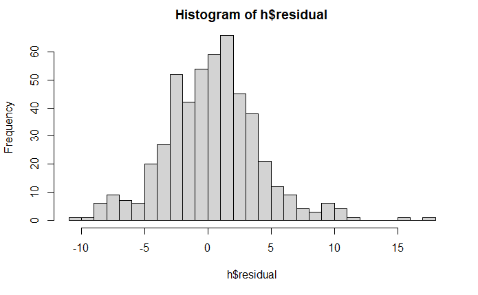

```r
hist(h$residual, breaks=30)
```

H0: error berdistribusi normal H1: error tidak berdistribusi normal (harapannya pvalue > alpha agar keputusan yang diambil adalah gagal tolak H0)

```r
shapiro.test(h$residual)
```

```
    Shapiro-Wilk normality test

data:  h$residual
W = 0.98018, p-value = 0.000002859
```

> p value < 0.005 tolak H0

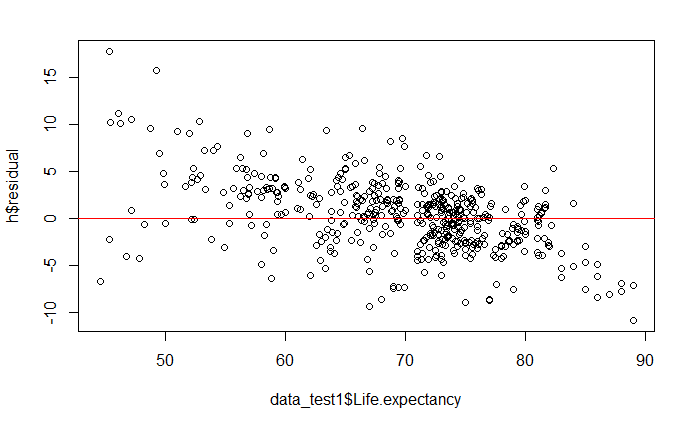

```r
library(lmtest)
plot(data_test1$Life.expectancy, h$residual)
abline(h = 0, col = "red")
```

$$H_0: Variansi\ error\ menyebar\ konstan\ (Homoscedasticity)\\
H_1: Variansi\ error\ menyebar\ tidak\ konstan\ membentuk\ pola\
(Heteroscedasticity)$$
Breusch-Pagan hypothesis test: (harapannya p-value > alpha agar gagal tolak H0)

```r
bptest(both_model)
```

```
    studentized Breusch-Pagan test

data:  both_model
BP = 119.4, df = 11, p-value < 0.00000000000000022
```

```r
vif(both_model)
```

```
                      Schooling                        HIV.AIDS                 Adult.Mortality
                       3.287398                        1.438910                        1.761999
Income.composition.of.resources                             GDP                             BMI
                       2.811737                        1.359024                        1.594287
                          Polio                   infant.deaths                         Alcohol
                       1.659005                        1.540441                        1.771036
                        Measles                      Diphtheria
                       1.467346                        1.671044
```